# Module 4 Project

Ana Pirosca, Lauren Geary, Blake Prall, Vanessa JeanGilles

2023-10-03

# Introduction

In the anole project, we are focusing on assessment of morphological and allometric differences within anoles, in particular, visualization and analyzation of hind-limb length and size covariation within niches. Hagey et al. (2017) is a recent study that was concerned with the hindlimb-ecomorph relationship of anoles. In this study, they phylogenetic GLS models to analyze their data, which are the same type of models that we will use to answer our question.

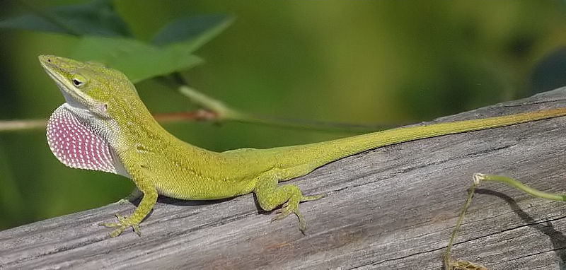

Anolis lizard

# Methods

In order to answer our question, we will create four different PGLS models and then compare them to determine which has the best fit according to a similar method used by Chen et al. (2022). To compare our models, we will use AIC operations, in particular AICc and AICw, and which ever model has the best results will tell us what the answer to our question is.

### Adding Code with Chunks

```r
x<-1:100
mean(50)
```

```
## [1] 50
```

```r
anole <- read_csv("anole.dat.csv")
anole.eco <- read_csv("anole.eco.csv")
anole.tree <- read.tree("anole.tre")
```

```r
anole2 <- anole%>%
left_join(anole.eco)%>%
  filter(!Ecomorph%in%c("U","CH"))%>%
  na.omit()
anole.log <- anole2%>%
  mutate_at(c("SVL", "HTotal","PH","ArbPD"),log)
```

# Results

The results show that PGLS under BM with ecomorphological data is the best model. This can be taken to mean that the traits have evolved randomly within each lineage specifically.

```r
### phylogenetic GLS models

#PGLS under BM, no ecomorph
pgls.BM1 <- gls(HTotal ~SVL, correlation = corBrownian(1,phy = anole.tree,form=~Species),data = anole.log, method = "ML")

#PGLS under BM, w ecomorph
pgls.BM2 <- gls(HTotal ~SVL * Ecomorph2, correlation = corBrownian(1,phy = anole.tree,form=~Species),data = anole.log, method = "ML")

#PGLS under OU, no ecomorph
pgls.OU1 <- gls(HTotal ~SVL, correlation = corMartins(0,phy = anole.tree,form=~Species),data = anole.log, method = "ML")

#PGLS under OU, w, ecomorph
pgls.OU2 <- gls(HTotal ~SVL * Ecomorph2, correlation = corMartins(0,phy = anole.tree,form=~Species),data = anole.log, method = "ML")
```

```r
#AIC operations
anole.phylo.aic <- AICc(pgls.BM1,pgls.BM2,pgls.OU1,pgls.OU2)
anole.phylow.aicw <- aicw(anole.phylo.aic$AICc)
```

```r
#AIC ALTERED operations
kable(anole.phylo.aic, caption = "AIC Summary for Anole Phylogenetic Models")
```

AIC Summary for Anole Phylogenetic Models

|  | df | AICc |
| --- | --- | --- |
| pgls.BM1 | 3 | -63.66118 |
| pgls.BM2 | 13 | -92.98036 |
| pgls.OU1 | 4 | -57.31864 |
| pgls.OU2 | 14 | -84.89770 |

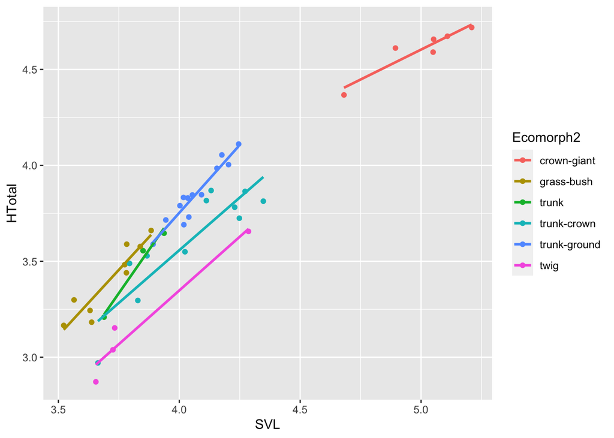

```r
ggplot(anole.log, aes(x = SVL, y = HTotal, color = Ecomorph2)) +
  geom_point() +
  geom_smooth(method = "lm", se = FALSE)
```

```r
#add phylo-corrected residuals
anole.log <- anole.log%>%
  mutate(phylo.res=residuals(pgls.BM2))
```

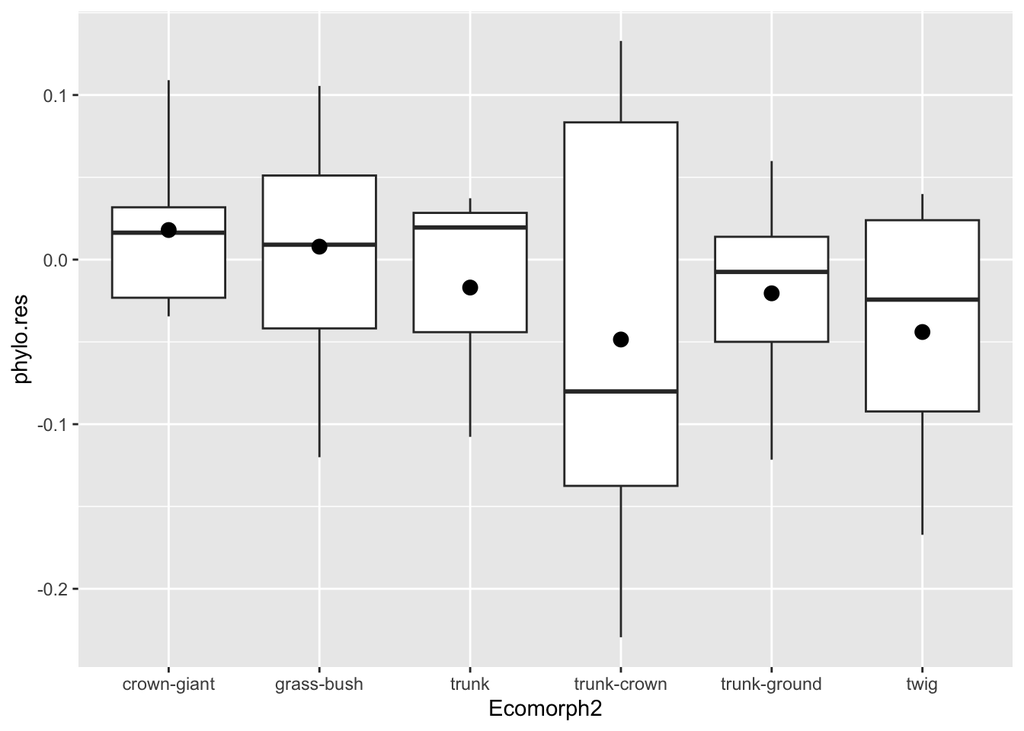

Boxplot of phylogenetically corrected hindlimb residuals versus anole ecomorph

```r
#plot residuals
p.eco.phylo <- anole.log%>%
ggplot(aes(x=Ecomorph2,y=phylo.res)) +geom_boxplot() +stat_summary(fun=mean, geom="point", size=3)

print(p.eco.phylo)
```

# Discussion

The results indicate that the traits evolve randomly within each ecological niche. This signifies that each niche has a particular hind-limb to body length ratio that is advantageous there in particular.

# Author Contributions

Ana produced the AIC table and wrote the Author Contributions. Lauren created the regression plot, and created the reference file. Blake added an image of an anole and wrote the introduction. Vanessa wrote the Methods, Results, and Discussion.

Nice work, especially considering this was your first crack at something like this!

Total points: 20

# References

Chen, Zhuoyu, Xiaojun Wang, Yu Song, Qinglu Zeng, Yao Zhang, and Haiwei Luo. 2022. “Prochlorococcus Have Low Global Mutation Rate and Small Effective Population Size.” *Nature Ecology & Evolution* 6 (February). https://doi.org/10.1038/s41559-021-01591-0.

Hagey, Travis J, Scott Harte, Mathew Vickers, Luke J Harmon, and Lin Schwarzkopf. 2017. “There’s More Than One Way to Climb a Tree: Limb Length and Microhabitat Use in Lizards with Toe Pads.” *PloS One* 12 (9): e0184641.